# Introduction to the Command Line (Terminal) and the R Language Syntax

# 4) More Visualization

# 4.1) Scatterplot

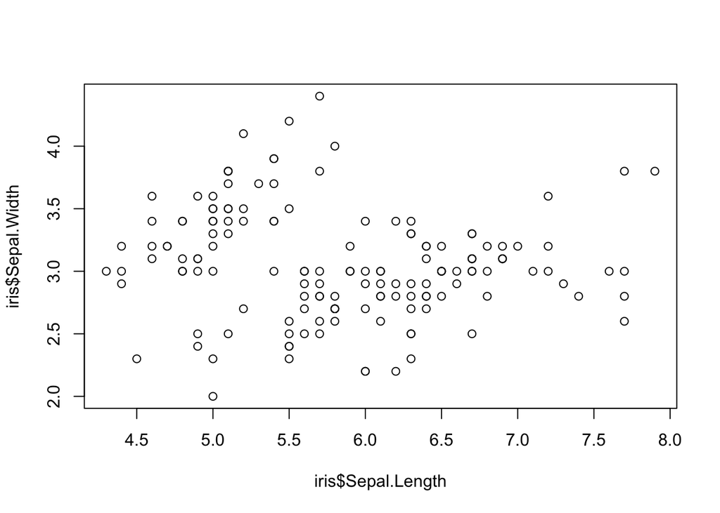

```r
plot(data=iris, iris$Sepal.Length, iris$Sepal.Width) ## R will complain about this command
```

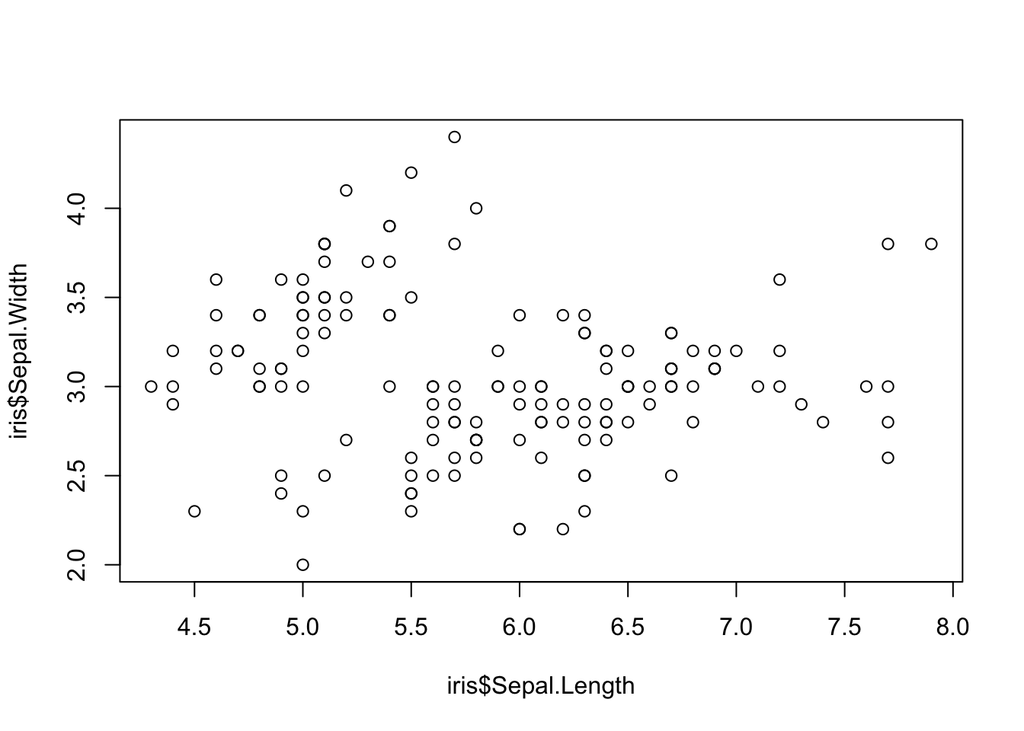

```r
plot(iris$Sepal.Length, iris$Sepal.Width) ## According to the error, this was plotted using a different synthax
```

# 4.2) Boxplot

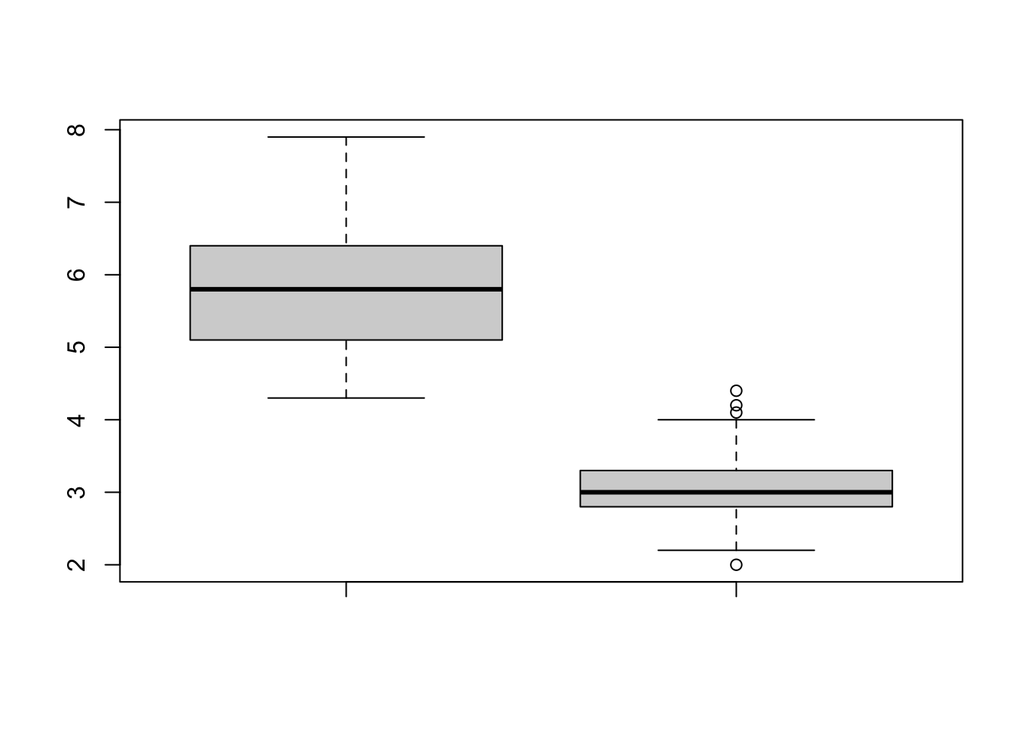

```r
boxplot(data=iris, iris$Sepal.Length, iris$Sepal.Width)
```

# 5) Data Visualization with specialized libraries

- In R, there are packages designed with the purpose of making good-looking graphics. This is the case with the ggplot2. The chunk below installs the ggplot2 library, loads the library into the R environment and then plots the data present in the iris data-frame.
- You can uncomment the installation line if you need to install it

# 5.1) Ggplot2

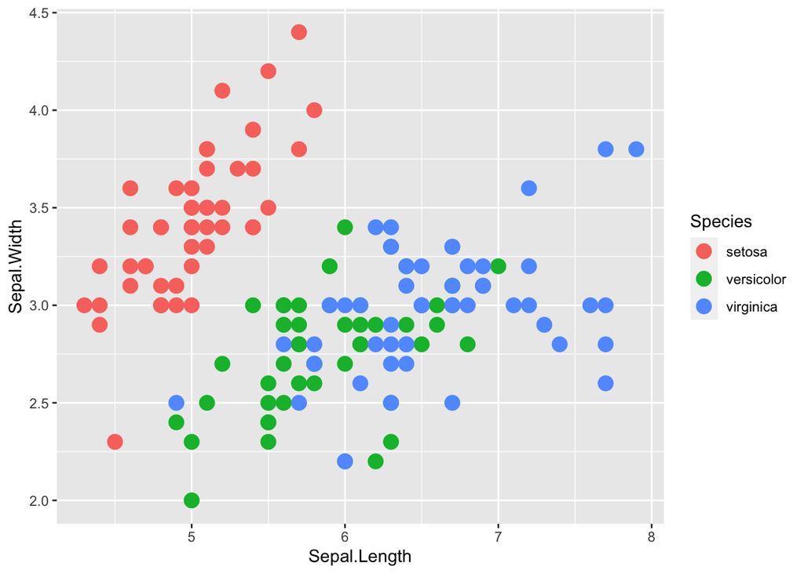

```r
#install.packages("ggplot2")
library(ggplot2)
ggplot(data=iris, aes(x=Sepal.Length, y=Sepal.Width, color=Species)) + geom_point(size=4)
```

In our activities to visualize human genomic data, we will use a library called qqman, to visualize the biological association, through a plot known as the Manhattan plot.

# 5.2) Visualizing GWAS

- The simplest definition of a GWAS is the statistical or significant association between a phenotype (trait) and a genotype. This association can also be called *biological association*.
- Information about association of SNPs with Huntington’s Disease can be found at the Chaves 2019 Huntington’s disease paper

# 5.3.1) Package installation

- We need to install and load package qqman

```r
## install.packages("qqman")
library(qqman)
```

- After, we load data-frame to be visualized
- Exact location of text file in your system needs to be determined

```r
GWAS_TABLE <- read.table("~/Desktop/Arquivos/chr4.txt",
                         sep = " ",
                         header = T)
```

# 5.3.3) Get information about object with head()

- Use head() function to inspect the data-frame just loaded

```r
head(GWAS_TABLE, n = 10)
```

|  | CHR | SNP | BP | P |
| --- | --- | --- | --- | --- |
| 1 | 4 | chr4:128096 | 128096 | 0.0133500 |
| 2 | 4 | chr4:516586 | 516586 | 0.0076260 |
| 3 | 4 | chr4:523979 | 523979 | 0.0024960 |
| 4 | 4 | chr4:527217 | 527217 | 0.0217400 |
| 5 | 4 | chr4:566177 | 566177 | 0.0008988 |
| 6 | 4 | chr4:578679 | 578679 | 0.0162100 |
| 7 | 4 | chr4:578790 | 578790 | 0.0103700 |
| 8 | 4 | chr4:579307 | 579307 | 0.0334600 |
| 9 | 4 | chr4:580259 | 580259 | 0.0190400 |
| 10 | 4 | chr4:585318 | 585318 | 0.0317600 |

# 5.3.4) Plotting GWAS data-frame

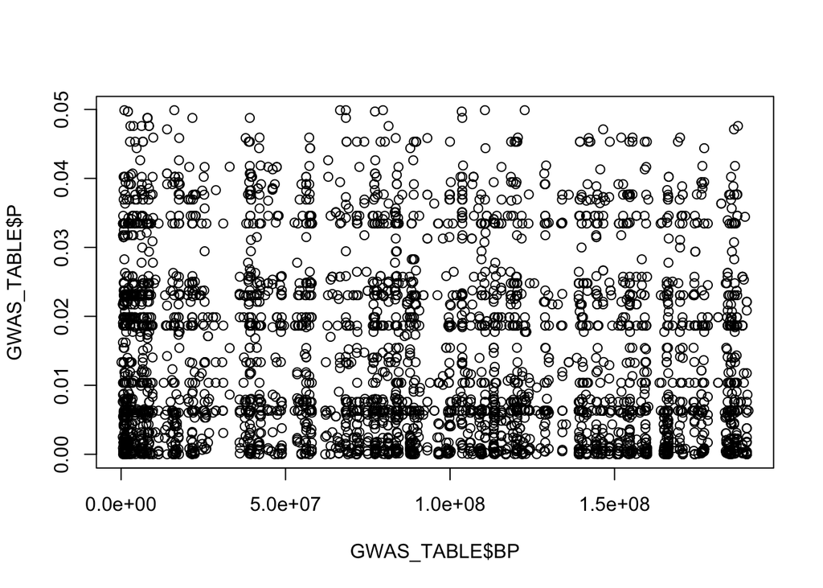

```r
plot(data=GWAS_TABLE, GWAS_TABLE$BP, GWAS_TABLE$P) ## R complains
```

# 5.3.4) Plotting GWAS data-frame

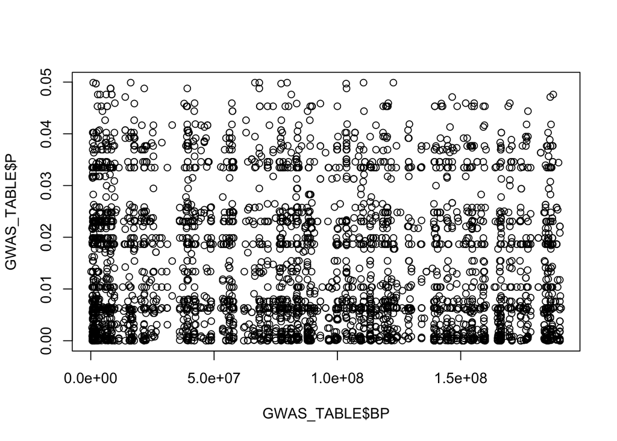

```r
plot(GWAS_TABLE$BP, GWAS_TABLE$P) ## R does not complain
```

# 5.4) Boxplot

- Boxplot

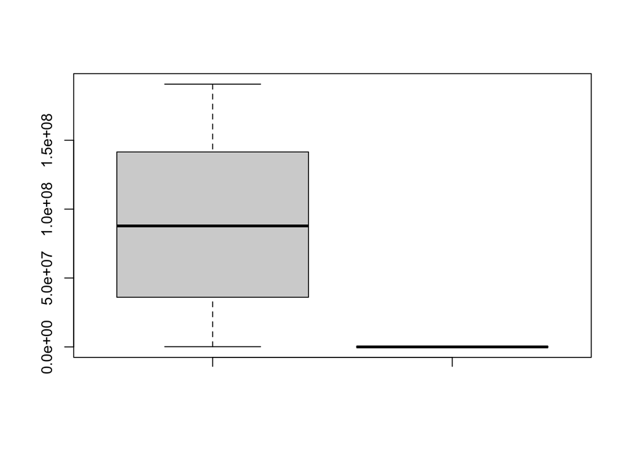

```r
boxplot(data=GWAS_TABLE, GWAS_TABLE$BP, GWAS_TABLE$P)
```

# 5.5) Boxplot

- Compare the chromosomal coordinates and the values of the p-values in the boxplot above
- The chunk below allows one to ommit NA values in data-frame

```r
GWAS_TABLE_Ommit <- na.omit(GWAS_TABLE)
```

A seguir, criamos uma variável que armazena as posições das SNPs a serem realçadas em verde no Manhattan plot. Estas SNPs são mutações biológica e estatisticamente associadas à Doença de Huntington no gene de uma sortilina, localizada em proximidade física ao gene da proteína huntingtina mutada, a qual é a causadora medeliana (segue as leis de segregação genética de Mendel) da Doença de Huntington.

# 5.6) Create vector to highlight genome coordinates in Manhattan plot

```r
SNP_HIGHLIGHT <- c("chr4:3043512","chr4:3043513","chr4:3048207","chr4:3224216",
                   "chr4:3231772","chr4:3233844","chr4:3235081","chr4:3235084",
                   "chr4:3236881","chr4:3236883","chr4:3241845","chr4:3243804",
                   "chr4:3263138","chr4:3265130","chr4:3265710","chr4:3314646",
                   "chr4:3380088","chr4:3409359","chr4:3411110","chr4:3415336",
                   "chr4:3415378","chr4:3438643","chr4:3446091","chr4:3449886",
                   "chr4:3473066","chr4:3476809","chr4:3480439","chr4:3487151",
                   "chr4:3496058","chr4:3496110","chr4:3506933","chr4:3508752",
                   "chr4:3510957","chr4:3512690","chr4:3517746","chr4:3518190",
                   "chr4:3529671","chr4:3532327","chr4:3533066","chr4:3746133",
                   "chr4:3747842","chr4:3748134","chr4:3765305","chr4:3765336",
                   "chr4:3944253","chr4:3944752","chr4:3944888","chr4:3946166",
                   "chr4:3946175","chr4:3969218","chr4:4051294","chr4:4076788",
                   "chr4:4103104","chr4:4103105","chr4:4109198","chr4:4109210",
                   "chr4:4240627","chr4:4242705","chr4:4243668","chr4:4245210",
                   "chr4:4245510","chr4:4245513","chr4:4245591","chr4:4245926",
                   "chr4:4245929","chr4:4246109","chr4:4246433","chr4:4246453",
                   "chr4:4246457","chr4:4246497","chr4:4249414","chr4:4249415",
                   "chr4:4249484","chr4:4271623","chr4:4275306","chr4:4304749",
                   "chr4:4318931","chr4:4318970","chr4:4319564","chr4:4319728",
                   "chr4:4319750","chr4:4322078","chr4:4709657","chr4:4732282",
                   "chr4:4789635","chr4:4822960","chr4:4824890","chr4:4825092",
                   "chr4:4825180","chr4:4865316","chr4:4865321","chr4:5018702",
                   "chr4:5812778","chr4:5814082","chr4:5833660","chr4:5833899",
                   "chr4:5835541","chr4:5851205","chr4:5862752","chr4:5862938",
                   "chr4:5862943","chr4:5901873","chr4:5905499","chr4:5906287",
                   "chr4:6018891","chr4:6019046","chr4:6020190","chr4:6020367",
                   "chr4:6025638","chr4:6025656","chr4:6025766","chr4:6026058",
                   "chr4:6083488","chr4:6204935","chr4:6235553","chr4:6237142",
                   "chr4:6238466","chr4:6239906","chr4:6240929","chr4:6245022",
                   "chr4:6245618","chr4:6245732","chr4:6245915","chr4:6246075",
                   "chr4:6246373","chr4:6246959","chr4:6290594","chr4:6292020",
                   "chr4:6294095","chr4:6298375","chr4:6316092","chr4:6321396",
                   "chr4:6324647","chr4:6324785","chr4:6327669","chr4:6328354",
                   "chr4:6328507","chr4:6333130","chr4:6333559","chr4:6333669",
                   "chr4:6335966","chr4:6435341","chr4:6435486","chr4:6435926",
                   "chr4:6437191","chr4:6437197","chr4:6457121","chr4:6457131",
                   "chr4:6457132","chr4:6568390","chr4:6570032","chr4:6570768",
                   "chr4:6596360","chr4:6613252","chr4:6613462","chr4:6620991",
                   "chr4:6624771","chr4:6626154","chr4:6641969","chr4:6642090",
                   "chr4:6644466","chr4:6644467","chr4:6644468","chr4:6647889",
                   "chr4:6648300","chr4:6662665","chr4:6663319","chr4:6663715",
                   "chr4:6674554","chr4:6678553","chr4:6678599","chr4:6690535",
                   "chr4:6698664","chr4:6698667","chr4:6698706","chr4:6720572",
                   "chr4:6911679","chr4:6985889","chr4:6987394","chr4:7002344",
                   "chr4:7004495","chr4:7004506","chr4:7005196","chr4:7005199",
                   "chr4:7024077","chr4:7024398","chr4:7029430","chr4:7031064",
                   "chr4:7044357","chr4:7044380","chr4:7048842","chr4:7052115",
                   "chr4:7055253","chr4:7064243","chr4:7067765","chr4:7073187",
                   "chr4:7074027","chr4:7677967","chr4:7701947","chr4:7702795",
                   "chr4:7703505","chr4:7703807","chr4:7704795","chr4:7704818",
                   "chr4:7709703","chr4:7712150","chr4:7714490","chr4:7733843",
                   "chr4:7735162","chr4:7735164","chr4:7736103","chr4:7736112")
```

# 5.7) Biological Association Visualization: Manhattan Plot

- Finally, we plot the Manhattanh plot graph

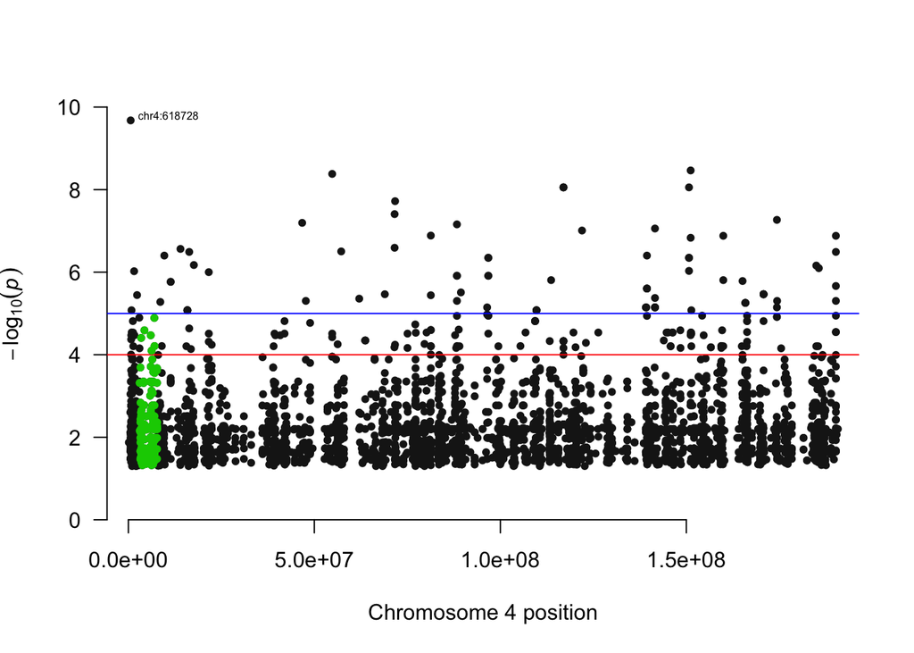

```r
manhattan(GWAS_TABLE_Ommit,
          highlight = SNP_HIGHLIGHT,
          annotateTop = T,
          annotatePval = 0.20,
          genomewideline = -log10(0.0001))
```